# 颅骨骨髓 BCR：年轻与年老

**查看分析代码**

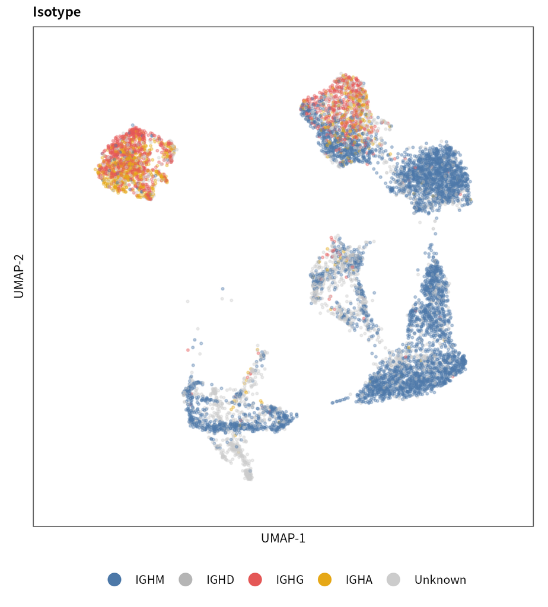

```r
print(p_iso_show)
```

图 02d. 颜色是抗体类别。灰色是恒定区没测到，细胞仍可能有重链。

**查看分析代码**

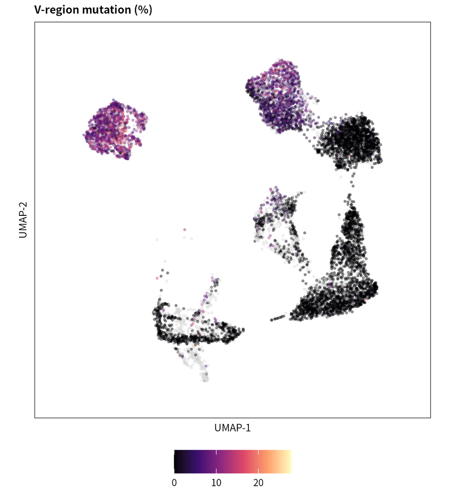

```r
print(p_mu_show)
```

图 02e. 颜色是重链 V 区突变百分比。灰色是突变值缺失。

## 图表数据

供者短编号和样本的对应表在 study_design.xlsx。每张图的 PDF、PNG 和作图用 Excel 列在 figure_table_map.xlsx。下载时请保持 `tables/` 和 `figures/` 的相对位置，链接才打得开。

- 图 01 Marker 点图：PDF，PNG，作图 Excel
- 图 02 亚型 UMAP：PDF，PNG，作图 Excel
- 图 02b UMAP 年龄：PDF，PNG，作图 Excel
- 图 02c UMAP 克隆大小：PDF，PNG，作图 Excel
- 图 02d UMAP 同种型：PDF，PNG，作图 Excel
- 图 02e UMAP 突变：PDF，PNG，作图 Excel
- 图 03 重链回收率：PDF，PNG，作图 Excel
- 图 04 亚型组成：PDF，PNG，作图 Excel
- 图 05 重点亚型比例：PDF，PNG，作图 Excel
- 图 05s 其余亚型比例：PDF，PNG，作图 Excel
- 图 06 全库扩增：PDF，PNG，作图 Excel
- 图 07 主要亚型内扩增：PDF，PNG，作图 Excel
- 图 07s 其余亚型内扩增：PDF，PNG，作图 Excel
- 图 08 同种型构成：PDF，PNG，作图 Excel
- 图 09 类别转换：PDF，PNG，作图 Excel
- 图 10 IGHV 使用率：PDF，PNG，作图 Excel
- 图 11 主要亚型 SHM：PDF，PNG，作图 Excel
- 图 12 Memory B 分同种型 SHM：PDF，PNG，作图 Excel
- 图 13 Top 10 克隆占比：PDF，PNG，作图 Excel
- 图 14 Shannon：PDF，PNG，作图 Excel
- 图 16 同种型内扩增：PDF，PNG，作图 Excel
- 图 17 Plasma 分同种型 SHM：PDF，PNG，作图 Excel
- 图 18 供者克隆大小：PDF，PNG，作图 Excel
- 图 19 年轻年老克隆大小：PDF，PNG，作图 Excel
- 图 20 亚型克隆大小甜甜圈：PDF，PNG，作图 Excel
- 图 21 扩增细胞亚型甜甜圈：PDF，PNG，作图 Excel
- 图 22 Gini-Simpson：PDF，PNG，作图 Excel
- 图 23 STARTRAC 扩增：PDF，PNG，作图 Excel
- 图 24 STARTRAC 亚型间共享：PDF，PNG，作图 Excel
- 图 25 IgG 浆细胞扩增：PDF，PNG，作图 Excel
- 图 26 IgG 浆细胞 SHM：PDF，PNG，作图 Excel
- 图 27 IgG 浆细胞 Gini：PDF，PNG，作图 Excel
- 图 28 IgG 浆细胞 Top 10：PDF，PNG，作图 Excel
- 图 29 IgG 浆细胞 IGHV 使用频率：PDF，PNG，作图 Excel

**查看分析代码**

```r
session_txt <- c(
  paste("Quarto:", system2("quarto", "--version", stdout = TRUE)),
  capture.output(sessionInfo())
)
writeLines(session_txt, file.path(rdata_dir, "sessionInfo.txt"))
manifest_paths <- list.files(output_dir, recursive = TRUE, full.names = TRUE)
manifest_paths <- manifest_paths[!grepl("shm/|file_manifest.xlsx", manifest_paths)]
write_xlsx(tibble(path = manifest_paths, bytes = file.info(manifest_paths)$size), "file_manifest")
```